# Лабораторная работа №4

Турутин Дмитрий ФН11-33Б

26/11/2022

# Задание 1

Сохраните в формате pdf, затем в png диаграмму рассеивания зависимости расхода топлива (mpg) от веса автомобиля (wt) в mtcars. Также добавьте горизонтальную линию, проходящую, через среднее значение mpg. ### Решение

```r
# Используем tibble для красивого отображения datframe'а
library("dplyr")
data(mtcars)
mtcars_tibble <- as_tibble(mtcars)
mtcars_tibble
```

```
## # A tibble: 32 × 11
##      mpg   cyl  disp    hp  drat    wt  qsec    vs    am  gear  carb
##    <dbl> <dbl> <dbl> <dbl> <dbl> <dbl> <dbl> <dbl> <dbl> <dbl> <dbl>
##  1  21       6  160    110  3.9   2.62  16.5     0     1     4     4
##  2  21       6  160    110  3.9   2.88  17.0     0     1     4     4
##  3  22.8     4  108     93  3.85  2.32  18.6     1     1     4     1
##  4  21.4     6  258    110  3.08  3.22  19.4     1     0     3     1
##  5  18.7     8  360    175  3.15  3.44  17.0     0     0     3     2
##  6  18.1     6  225    105  2.76  3.46  20.2     1     0     3     1
##  7  14.3     8  360    245  3.21  3.57  15.8     0     0     3     4
##  8  24.4     4  147.    62  3.69  3.19  20       1     0     4     2
##  9  22.8     4  141.    95  3.92  3.15  22.9     1     0     4     2
## 10  19.2     6  168.   123  3.92  3.44  18.3     1     0     4     4
## # … with 22 more rows
```

```r
mean <- mean(mtcars_tibble$mpg)
```

Сохранить график зависимости mpg от wt в **pdf**

```r
# pdf('plot.pdf')
{plot(mpg ~ wt, data = mtcars_tibble)
abline(h = mean)}
```

[figure not shown]

```r
# dev.off()
```

Сохранить график в **png**

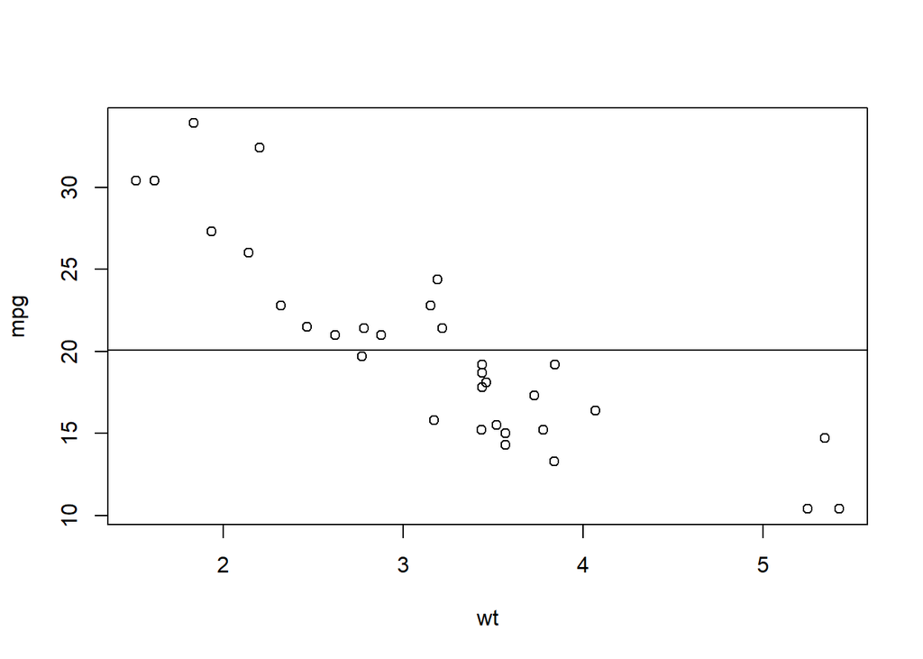

```r
# png('plot.png')
{plot(mpg ~ wt, data = mtcars_tibble)
abline(h = mean)}
```

```r
# dev.off()
```

# Задание 2

Есть набор данных – реакция пациента на лекарство в пяти дозировках:

```r
dose <- c(20, 30, 40, 45, 60)
drugA <- c(16, 20, 27, 40, 60)
dragB <- c(15, 18, 25, 31, 40)
```

Постройте график реакции пациента на первое лекарство. Укажите графические параметры – пунктирная линия, и треугольники вместо точек. Добавьте заголовок красного цвета. Добавьте подписи осей. Границу по x укажите (0; 60) по y (0;70) ### График реакции на первое лекарство

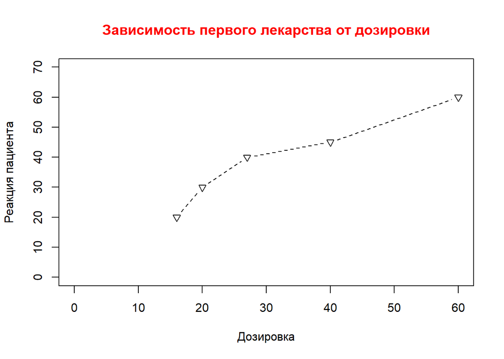

```r
opar <- par(no.readonly=T)
par(lty=2, pch=6)
plot(dose ~ drugA, main="Зависимость первого лекарства от дозировки", col.main="red", xlab="Дозировка", ylab="Реакция пациента", xlim=c(0,60), ylim=c(0,70), type="b")
```

```r
par(opar)
```

Поянения:

- lty – выбрать тип линии (2 ~ пунктирная)
- pch – выбрать тип точек (6 ~ треугольники)
- main – заголовок
- col.main – цвет заголовка
- ylab – подпись для оси **Oy**
- xlab – подпись для оси **Ox**
- xlim – расставить пределы по оси x
- ylim – расставить пределы по оси y
- type – тип графика (b ~ линия)

# Задание 3

Тот же набор

```r
dose <- c(20, 30, 40, 45, 60)
drugA <- c(16, 20, 27, 40, 60)
drugB <- c(15, 18, 25, 31, 40)
```

*Задача:*

- Отобразить сравнение эффектов от препаратов в одном окне.
- Выбрать различные типы линий и символов
- Добавить заголовок “Сравнение препаратов A и B”
- Добавить легенду

### Отобразить сравнение эффектов от препаратов в одном окне

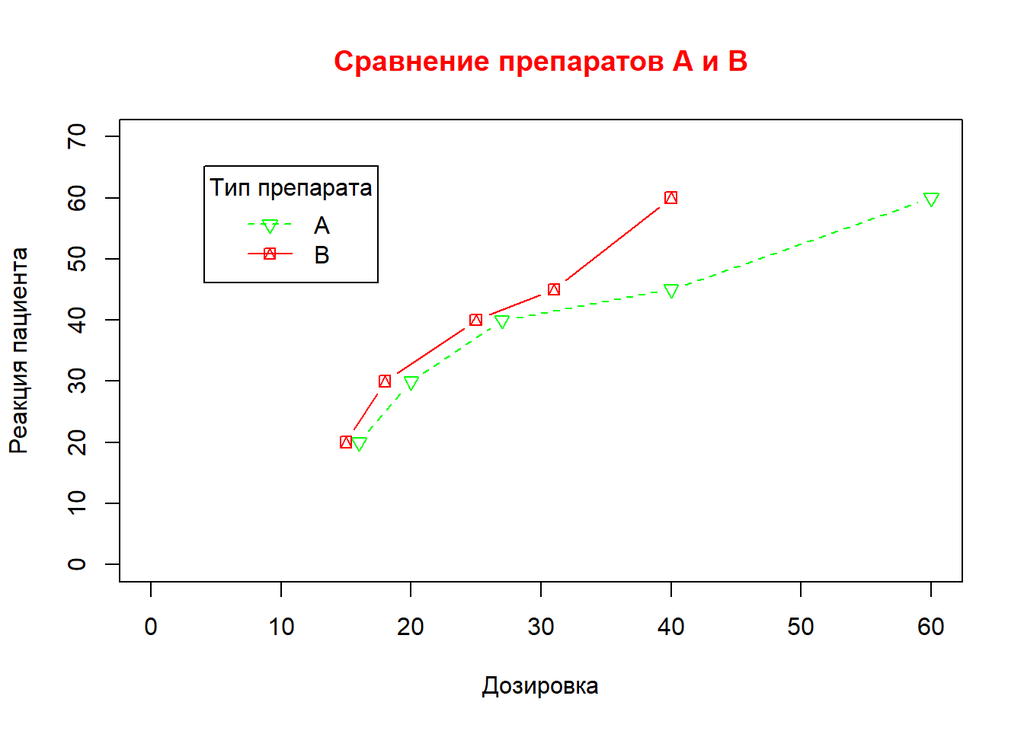

```r
plot(dose ~ drugA, main="Сравнение препаратов A и B", col.main="red", xlab="Дозировка", ylab="Реакция пациента", xlim=c(0,60), ylim=c(0,70), type="b", col="green", pch=6, lty=2)
# График второго препарата
lines(dose ~ drugB, type="b", pch=14, lty=1, col="red")
# Легенда
legend("topleft", inset=.1, title="Тип препарата", c("A", "B"), lty=c(2,1), pch=c(6, 14), col=c("green","red"))
```

# Задание 4

Отобразить 4 диаграммы boxplot() на одном поле на примере датасета iris

- Отобразить Sepal.Length
- Отобразить Sepal.Width
- Отобразить Petal.Length
- Отобразить Petal.Width

*в зависимости от Species*

```r
data(iris)

iris_tibble = as_tibble(iris)
names(iris_tibble)
```

```
## [1] "Sepal.Length" "Sepal.Width"  "Petal.Length" "Petal.Width"  "Species"
```

```r
iris_tibble
```

```
## # A tibble: 150 × 5
##    Sepal.Length Sepal.Width Petal.Length Petal.Width Species
##           <dbl>       <dbl>        <dbl>       <dbl> <fct>
##  1          5.1         3.5          1.4         0.2 setosa
##  2          4.9         3            1.4         0.2 setosa
##  3          4.7         3.2          1.3         0.2 setosa
##  4          4.6         3.1          1.5         0.2 setosa
##  5          5           3.6          1.4         0.2 setosa
##  6          5.4         3.9          1.7         0.4 setosa
##  7          4.6         3.4          1.4         0.3 setosa
##  8          5           3.4          1.5         0.2 setosa
##  9          4.4         2.9          1.4         0.2 setosa
## 10          4.9         3.1          1.5         0.1 setosa
## # … with 140 more rows
```

```r
unique(iris_tibble$Species)
```

```
## [1] setosa     versicolor virginica
## Levels: setosa versicolor virginica
```

### Для setosa

```r
par(mfrow=c(2, 2))
setosa <-  filter(iris_tibble, Species=="setosa")
setosa
```

```
## # A tibble: 50 × 5
##    Sepal.Length Sepal.Width Petal.Length Petal.Width Species
##           <dbl>       <dbl>        <dbl>       <dbl> <fct>
##  1          5.1         3.5          1.4         0.2 setosa
##  2          4.9         3            1.4         0.2 setosa
##  3          4.7         3.2          1.3         0.2 setosa
##  4          4.6         3.1          1.5         0.2 setosa
##  5          5           3.6          1.4         0.2 setosa
##  6          5.4         3.9          1.7         0.4 setosa
##  7          4.6         3.4          1.4         0.3 setosa
##  8          5           3.4          1.5         0.2 setosa
##  9          4.4         2.9          1.4         0.2 setosa
## 10          4.9         3.1          1.5         0.1 setosa
## # … with 40 more rows
```

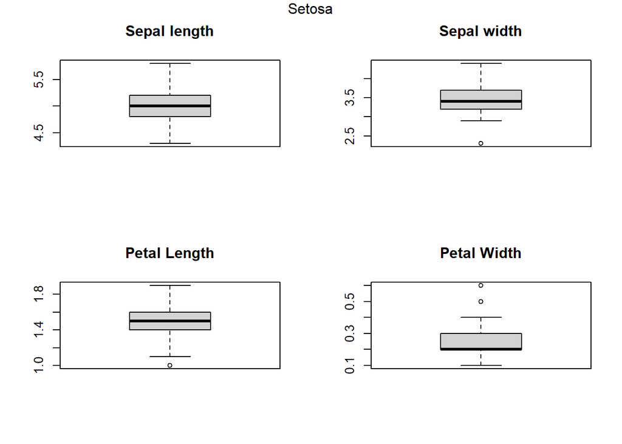

```r
boxplot(setosa$Sepal.Length, main="Sepal length")
boxplot(setosa$Sepal.Width, main="Sepal width")
boxplot(setosa$Petal.Length, main="Petal Length")
boxplot(setosa$Petal.Width, main="Petal Width")
mtext("Setosa", side = 1, line=-30, outer=T)
```

### Для versicolor

```r
par(mfrow=c(2, 2))
versicolor <-  filter(iris_tibble, Species=="versicolor")
versicolor
```

```
## # A tibble: 50 × 5
##    Sepal.Length Sepal.Width Petal.Length Petal.Width Species
##           <dbl>       <dbl>        <dbl>       <dbl> <fct>
##  1          7           3.2          4.7         1.4 versicolor
##  2          6.4         3.2          4.5         1.5 versicolor
##  3          6.9         3.1          4.9         1.5 versicolor
##  4          5.5         2.3          4           1.3 versicolor
##  5          6.5         2.8          4.6         1.5 versicolor
##  6          5.7         2.8          4.5         1.3 versicolor
##  7          6.3         3.3          4.7         1.6 versicolor
##  8          4.9         2.4          3.3         1   versicolor
##  9          6.6         2.9          4.6         1.3 versicolor
## 10          5.2         2.7          3.9         1.4 versicolor
## # … with 40 more rows
```

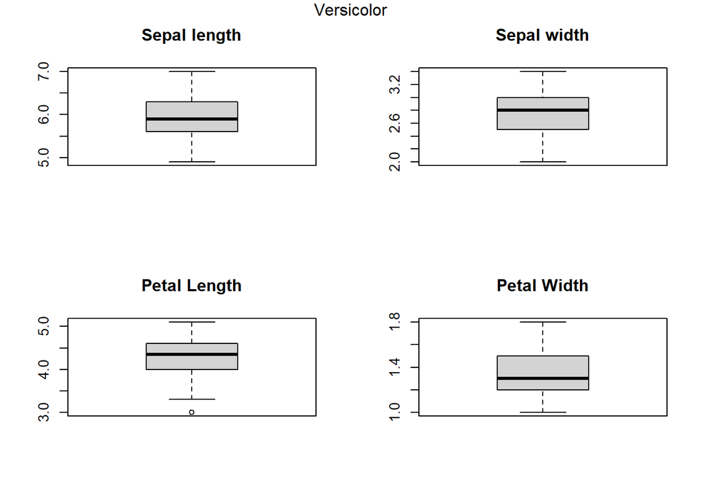

```r
boxplot(versicolor$Sepal.Length, main="Sepal length")
boxplot(versicolor$Sepal.Width, main="Sepal width")
boxplot(versicolor$Petal.Length, main="Petal Length")
boxplot(versicolor$Petal.Width, main="Petal Width")
mtext("Versicolor", side = 1, line=-30, outer=T)
```

### Для virginica

```r
par(mfrow=c(2, 2))
virginica <-  filter(iris_tibble, Species=="virginica")
virginica
```

```
## # A tibble: 50 × 5
##    Sepal.Length Sepal.Width Petal.Length Petal.Width Species
##           <dbl>       <dbl>        <dbl>       <dbl> <fct>
##  1          6.3         3.3          6           2.5 virginica
##  2          5.8         2.7          5.1         1.9 virginica
##  3          7.1         3            5.9         2.1 virginica
##  4          6.3         2.9          5.6         1.8 virginica
##  5          6.5         3            5.8         2.2 virginica
##  6          7.6         3            6.6         2.1 virginica
##  7          4.9         2.5          4.5         1.7 virginica
##  8          7.3         2.9          6.3         1.8 virginica
##  9          6.7         2.5          5.8         1.8 virginica
## 10          7.2         3.6          6.1         2.5 virginica
## # … with 40 more rows
```

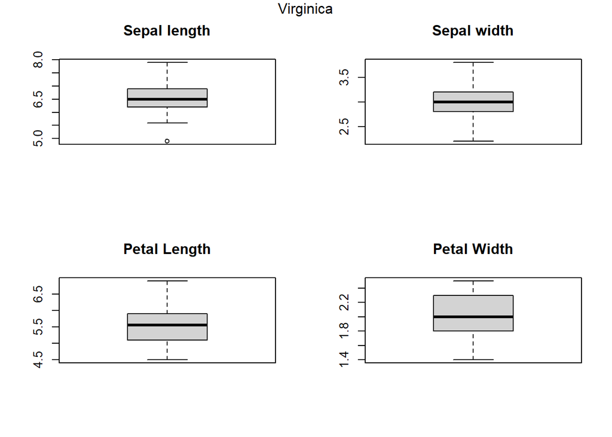

```r
boxplot(virginica$Sepal.Length, main="Sepal length")
boxplot(virginica$Sepal.Width, main="Sepal width")
boxplot(virginica$Petal.Length, main="Petal Length")
boxplot(virginica$Petal.Width, main="Petal Width")
mtext("Virginica", side = 1, line=-30, outer=T)
```